# Creating the Enemies

In this lesson, we’ll create the enemies that will move towards your base. These creatures can take lots of hits and are a core aspect of any tower defense game.

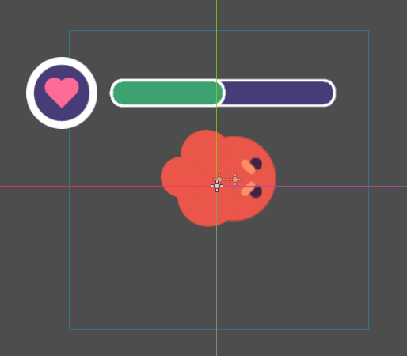

You will learn to:

- Move an object along a path.
- Use the hit and hurt boxes to take damage.
- Snap a life bar to a moving entity.
- Update the enemy’s life bar when it takes damage.

## Moving along a path in Godot

Following a geometric curve is one of the many ways to move objects in a game.

We can create a path manually or programmatically. This method is perfect for a tower defense game where the enemies are always walking along a pre-determined path.

In Godot, this feature comes built-in in the form of the

[figure not shown]

`Path2D` node.

We create a

[figure not shown]

`Path2D` node inside our game levels and add enemies as children. We use the

[figure not shown]

`PathFollow2D` node as the root of the enemy scene because it’s designed to move along a

[figure not shown]

`Path2D`. When we add enemies to the game, they automatically follow the parent path.

## Creating the enemy scene

Let’s create the enemy scene. We start with a *PathFollow2D* node as the root named *Enemy*. Save it as `res://Actors/Enemies/Enemy.tscn`.

Be sure to unselect *Loop* in the *Inspector* as we don’t want the enemy to go back to the beginning of the path once its reached the *PlayerBase*.

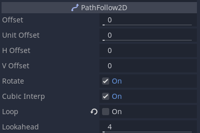

Don’t worry about the warning sign next to the node. It’s there to let you know it won’t function without a parent

[figure not shown]

`Path2D`.

I prepared an animated character for you that can instantiate in `res://Actors/Enemies/CutoutCharacter.tscn`.

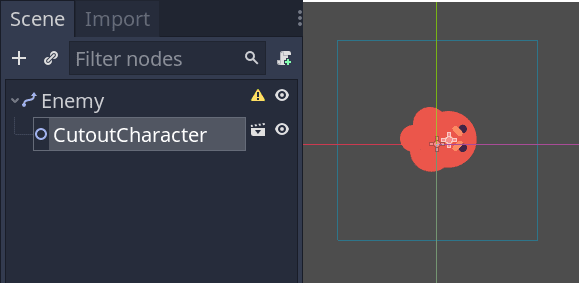

If you open it, you will see it has several sprites and an animation player with a looping `move` animation which makes them jiggle.

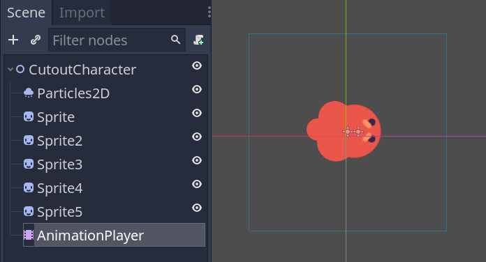

The scene also contains some particles that leave trails of red blobs. You can’t see them well because the sprites are hiding the node.

To see the particles, you can select all the sprites in the scene dock and turn off their visibility. They will look like this in-game as the enemies move along the trail.

You can move the *Particles2D* around to see how they draw a fading trail.

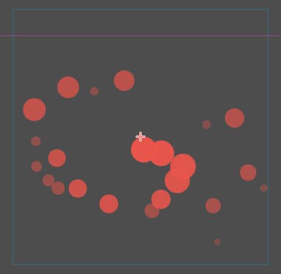

You can then close the scene without saving to restore the visibility of the sprites.

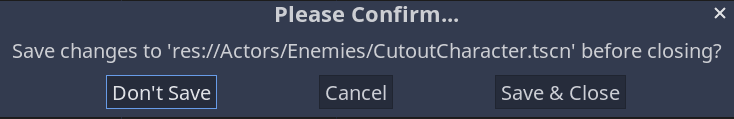

We want the enemy to take and deal damage so we add a `HurtBoxArea2D` and a `HitBoxArea2D`.

Select both nodes and set the team to *Enemy* in the *Inspector*.

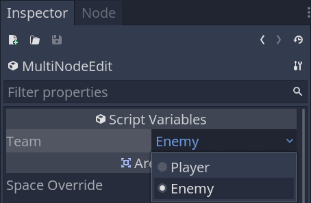

They both need a collision shape to function so add a

[figure not shown]

`CollisionShape2D` node as a child of each with a

[figure not shown]

`CircleShape2D`.

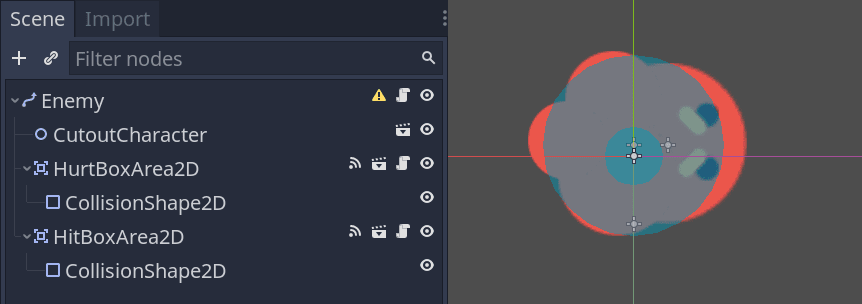

We need tower weapons to detect the enemies so we add another *Area2D* which I’ve named *VisibleArea2D*. We keep the hit and hurt system separate from range detection so we don’t risk breaking either by making tweaks to relevant nodes.

Assign the area’s *Collision -> Layer* to the “enemies” physics layer (layer `3`) and remove the *Collision -> Mask* bits. We only want the weapons to detect the node and nothing else. You can also turn off its *Monitoring* property.

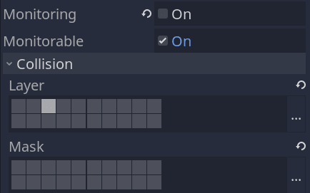

Add a

[figure not shown]

`CollisionShape2D` with a

[figure not shown]

`CircleShape2D` for its *Shape*.

## Using animations to appear and disappear

Next, we add fade in and fade out animations.

Add an

[figure not shown]

`AnimationPlayer` node to the scene, select it, and create a new animation named “spawn”. We want this one to play automatically when we run the game, so click the *Autoplay On Load* button to the right of the animation drop-down menu.

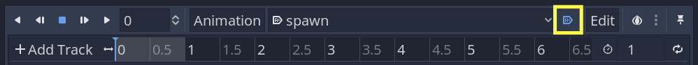

We want to animate the enemy node’s *Modulate* property going from a transparent white to an opaque white in about half a second to keep it short.

We also create a track that disables the *HurtBoxArea2D*’s collision shape so the enemy can’t take damage while it’s appearing. We set the *Disabled* property back to false when it’s fully opaque.

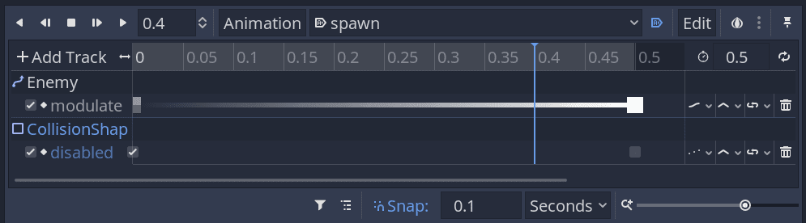

Now, create a new animation named “disappear”. It animates the *Enemy*’s modulate property backward, going from an opaque white to a transparent one, making it fade out. I made the animation last `0.25` seconds.

We also want to add a call method track and call `queue_free()` at the end of the animation to delete the instance.

To do so, click the *Add Track* button in the top-left of the *Animation* panel and click *Call Method Track*. The track should target the *Enemy* node.

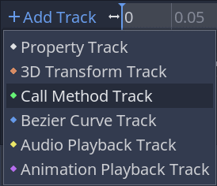

Right-click on the function call track at the end of the animation to insert a key.

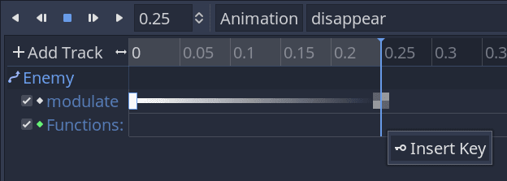

Select `queue_free()` from the list of available methods.

Here’s the complete animation.

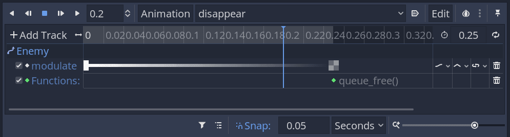

Let’s get coding and testing the enemy movement before we add the health bar.

## Moving along the path

Attach a script to the root node and save it.

We will start with the movement. We define a `speed` at which we want the enemy to move in pixels per second.

The

[figure not shown]

`PathFollow2D` class provides two properties to move our enemy. `offset` is the distance along the path in pixels. `unit_offset` is the distance along the path as a percentage . In other words, a `unit_offset` of `1.0` means the enemy has reached the end of the path.

The spawn animation will trigger automatically as we set it to do so in the animation player.

```
class_name Enemy
extends PathFollow2D

# Movement speed in pixels per second.
export var speed := 64.0

onready var _anim_player := $AnimationPlayer
# To play the move animation, we need a reference to the CutoutCharacter's
# animation player.
onready var _cutout_anim_player := $CutoutCharacter/AnimationPlayer

# The enemy will move thanks to the `_physics_process()` callback.
# But at the start of the game, we don't want to move until it finished its
# spawn animation.
func _ready() -> void:
    set_physics_process(false)


func _physics_process(delta: float) -> void:
    # Every frame, we move forward along the path.
    offset += speed * delta

    # If we reached the end of the path, we free the enemy.
    if unit_offset >= 1.0:
        set_physics_process(false)
        disappear()


# We define a function to let another system trigger enemy movement.
func move() -> void:
    set_physics_process(true)
    _cutout_anim_player.play("move")


func disappear() -> void:
    _anim_player.play("disappear")
```

## Dealing damage to the player base

When *Enemies* complete their movement, that means they’ve reached the player’s main structure.

At this point, we make them disappear and damage the player base.

In this demo, enemies will instantly hit the player base. We won’t let them attack the building periodically until the player towers kill them.

We don’t have anything to do here: the hitbox will automatically interact with the building’s hurt box. That’s the magic of Godot’s area nodes.

## Taking damage and making the enemy die

Enemies should know when their health depletes so they can destroy themselves.

We define two new properties to represent their current and maximum health.

But first, let’s add a life bar to it to visualize how much health they have left.

I prepared the life bar for you in this project. It’s a plain

[figure not shown]

`TextureProgress` node with a

[figure not shown]

`TextureRect` to display a sprite to its left. If you’d like to learn how to create one, check out the *JRPG UI* chapter.

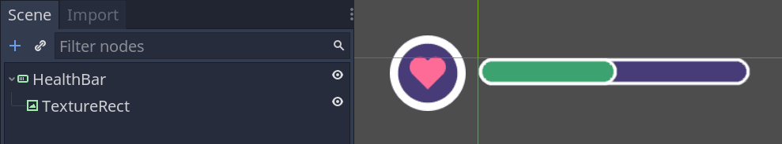

Here, I want to teach you a more useful technique: having the bar follow the enemy in the game world. The game is from a top-down perspective so the *Enemy* will turn to follow the path. We need the bar to track the enemy’s movement and always stay upright.

We use a

[figure not shown]

`RemoteTransform2D` node that transfer the *Enemy*’s position to the bar. Add one and a

[figure not shown]

`Node2D` that we name *UIPivot* with a `UIHealthBar` scene as a child.

In the image below, I moved the *UIHealthBar* up and left to center it above the creature.

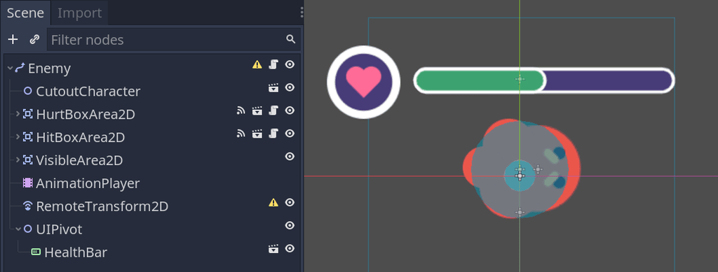

With a tiny bit of code, this setup allows us to have the bar follow the *Enemy*’s position without copying its rotation or scale.

It give us results like the image below.

[figure not shown]

The *RemoteTransform2D* needs a target node to push transforms to. Select it and in the *Inspector*, set the *Remote Path* to the *UIPivot* node.

Turn off its *Update -> Rotation* and *Update -> Scale* so it doesn’t rotate or scale the *UIHealthBar*.

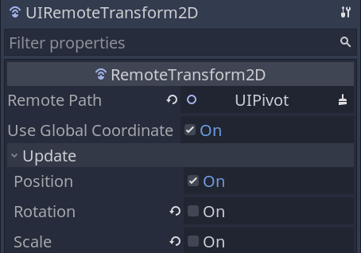

Open the enemy script again and add the following code to:

1. Taking damage when a hit lands on the *HurtBoxArea2D*.
2. Make the enemy die when its health reaches zero.
3. Add an amount of gold that the player will earn when the enemy dies.

```
signal died(gold_amount)

export var max_health := 15
# We set the `health` to `max_health` at the start of the game.
onready var health := max_health setget set_health

export var gold_value := 50

onready var _ui_pivot := $UIPivot
onready var _health_bar := $UIPivot/HealthBar


func _ready() -> void:
    # ...
    _ui_pivot.set_as_toplevel(true)

    _health_bar.max_value = max_health
    _health_bar.value = health

func set_health(value: int) -> void:
    health = clamp(value, 0, max_health)
    _health_bar.value = health

    if health < 1:
        die()


func die() -> void:
    emit_signal("died", gold_value)
    disappear()
```

The enemy won’t take damage yet. We have to connect the hurt box’s signal to the *Enemy* node.

Select *HurtBoxArea2D*, go to the *Node* dock, and connect its `hit_landed` signal to the *Enemy*.

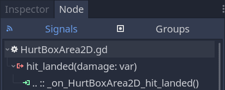

We subtract the damage value to the enemy’s health, going through the `set_health()` function. When the health depletes, the enemy dies.

```
func _on_HurtBoxArea2D_hit_landed(damage: int) -> void:
    set_health(health - damage)
```

## Testing the enemy

We have everything in place to make our enemy move and take damage. Let’s test our code.

Create a new temporary scene with a

[figure not shown]

`Path2D` node as the root.

You can design a path by clicking the green add point icon and clicking in the viewport.

Next, we add an enemy instance as a child of the path.

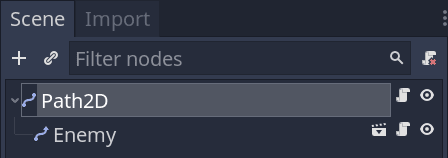

You will see the health bar rotates with the enemy. Don’t worry about that, it’s only in the editor. It will stay upright in the game.

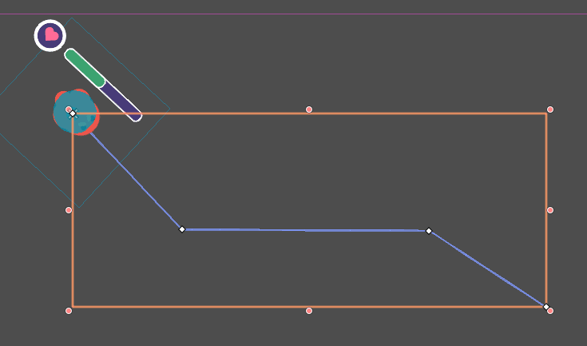

We could fix the look in the editor using Godot’s tool mode but we don’t have to worry about that because we instantiate enemies from code.

We can save the scene and attach a built-in script to the *Path2D* node.

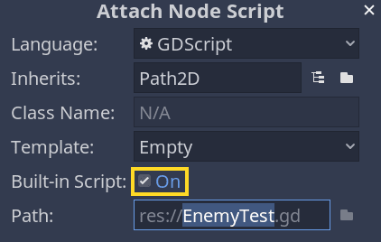

In the script, we define a temporary `ready` function that waits for the spawn animation to finish and makes the enemy move.

```
extends Path2D

func _ready() -> void:
    var scene_tree := get_tree()
    var enemy := $Enemy

    # We create a throwaway timer via the scene tree and wait for it to expire.
    yield(scene_tree.create_timer(0.5), "timeout")
    # Then, we start enemy movement.
    enemy.move()
```

To test the health and life bar, we create a timer in a loop and yield to inflict damage every second. That way, you will see the enemy take damage as if a tower was shooting it.

```
func _ready() -> void:
    # ...
    # Shorthand of `for i in range(5)`.
    for i in 5:
        # We wait for one second and damage the enemy.
        yield(scene_tree.create_timer(1.0), "timeout")
        enemy.health -= 1
```

You can run the scene to see the enemy both move and take damage. Once you’re done, you can close the scene and delete the file.

And with that, we have the foundation for pretty much all the base enemies you will have in a tower defense game.

In the next lesson, we will create enemy waves.

## Code reference

Here’s the final enemy script.

```
class_name Enemy
extends PathFollow2D

signal died(gold_amount)

# Movement speed in pixels per second.
export var speed := 64.0
# Amount of gold earned upon killing this enemy.
export var gold_value := 50

export var max_health := 15
onready var health := max_health setget set_health

onready var _ui_pivot := $UIPivot
onready var _health_bar := $UIPivot/HealthBar
onready var _anim_player := $AnimationPlayer
onready var _cutout_anim_player := $CutoutCharacter/AnimationPlayer


func _ready() -> void:
    set_physics_process(false)

    _ui_pivot.set_as_toplevel(true)

    _health_bar.max_value = max_health
    _health_bar.value = health


func _physics_process(delta: float) -> void:
    offset += speed * delta

    if unit_offset >= 1.0:
        set_physics_process(false)
        disappear()


func move() -> void:
    set_physics_process(true)
    _cutout_anim_player.play("move")


func disappear() -> void:
    _anim_player.play("disappear")


func die() -> void:
    emit_signal("died", gold_value)
    disappear()


func set_health(value: int) -> void:
    health = clamp(value, 0, max_health)
    _health_bar.value = health

    if health < 1:
        die()


func _on_HurtBoxArea2D_hit_landed(damage: int) -> void:
    set_health(health - damage)
```